# UNICEF REPORT

Forgotten Childhood: A Visual Exploration of Global Indicator

Author

Ilona Garnier

Published

April 27, 2025

## 📄**Report Summary**

The report will leverage data analysis and visualization techniques to elucidate the challenges faced by children worldwide, focusing on a specific indicator: the percentage of children suffering from at least three deprivations under homogeneous moderate standards. This report also include the UNICEF Metadata which offers additional contextual data about countries, such as GDP, inflation, and life expectancy at birth.

- Data for this analysis was sourced from **UNICEF**
- Please find the Tableau Version of this Report - [Click here](https://public.tableau.com/views/Assignment1-IlonaGarnier/Tableaudebord12?:language=fr-FR&:sid=&:redirect=auth&:display_count=n&:origin=viz_share_link)

This report seeks to highlight the significance of these challenges and promote concrete actions to enhance the well-being of children worldwide.

## **Understanding Child Deprivation**

*Measured by the percentage of children suffering from at least three deprivations under homogeneous severe standards. This indicator provides insights into the extent of multidimensional poverty experienced by children in different countries.*

**Child deprivation**, defined by UNICEF as the **lack of access to essential resources** such as education, drinking water, nutrition and health, particularly affects developing countries. However, even among the worst affected countries, there are **significant disparities**. Some nations, despite a low GDP, manage to improve children’s living conditions thanks to effective public policies, while others struggle to reduce social inequalities. The aim is therefore to gain a **better understanding of these disparities**, by cross-referencing data on child deprivation with socio-economic factors such as GDP.

[figure not shown]

## **Global State of child deprivation**:

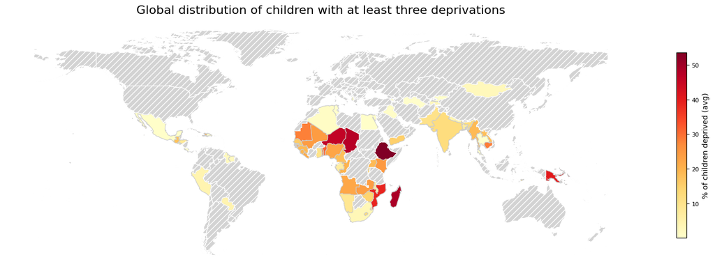

```python
import matplotlib.pyplot as plt

fig, ax = plt.subplots(1, 1, figsize=(15, 8))

merged_plot = merged.plot(
    column='mean_deprivation_rate',
    cmap='YlOrRd',
    linewidth=0.8,
    ax=ax,
    edgecolor='0.8',
    legend=True,
    legend_kwds={
        'label': "% of children deprived (avg)",
        'orientation': "vertical",
        'shrink': 0.45,
        'aspect': 18
    },
    missing_kwds={
        "color": "lightgrey",
        "edgecolor": "white",
        "hatch": "///",
        "label": "Missing values"
    }
)

cbar = ax.get_figure().get_axes()[-1]
cbar.tick_params(labelsize=8)

ax.set_title("Global distribution of children with at least three deprivations", fontsize=16)
ax.axis('off')
plt.tight_layout()
plt.show()
```

This map paints a powerful picture of inequality. It map shows the **percentage of children experiencing at least three deprivations** across **the globe - a reflection of unmet basic needs such as education, health, nutrition, and safety.**.

**Red color** reflect higher deprivation levels, while **yellow tones** indicate **lower levels**. These deeper shades don’t just indicate data points — they represent millions of children growing up without the essentials needed to thrive.

By visualizing these disparities, the map reveals **clear geographic patterns** in child well-being. **Sub-Saharan Africa stands out**, often showing the darkest shades, with consistently higher levels of deprivation compared to regions like Asia or Latin America. And even within sub-Saharan Africa, some countries are significantly more affected than others — highlighting the **complex layers of inequality** that exist not only between continents but within them.

This map is more than a diagnostic tool — it’s a call to action.Countries shaded in red demand **targeted policies and sustained support** to address systemic issues and give every child a fair chance. Because behind every percentage lies a child — and behind every red zone, a story waiting to be changed.

## **Top 10 of countries with the highest rate of child deprivation**

Let’s explore the socio-economic context of the world’s leading nations by analysing the average child deprivation rates in the top 10 countries.

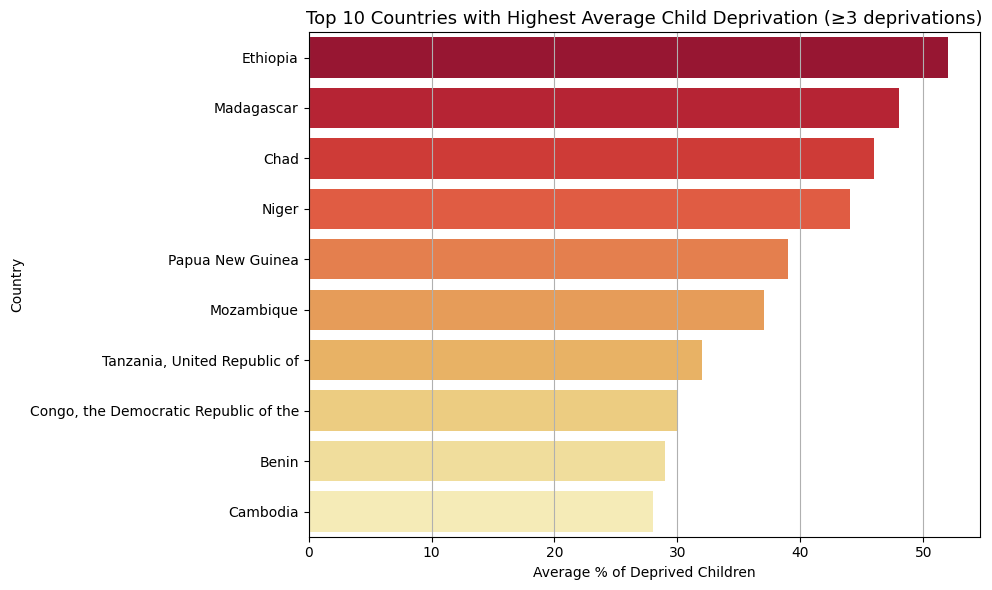

```python
import pandas as pd
import seaborn as sns
import matplotlib.pyplot as plt

data = {
    "country": [
        "Ethiopia", "Madagascar", "Chad", "Niger", "Papua New Guinea",
        "Mozambique", "Tanzania, United Republic of",
        "Congo, the Democratic Republic of the",
        "Benin", "Cambodia"
    ],
    "mean_deprivation_rate": [52, 48, 46, 44, 39, 37, 32, 30, 29, 28]
}

df_top10 = pd.DataFrame(data)

custom_palette = sns.color_palette("YlOrRd", n_colors=10)[::-1]

plt.figure(figsize=(10, 6))
sns.barplot(
    data=df_top10,
    y="country",
    x="mean_deprivation_rate",
    palette=custom_palette
)

plt.title("Top 10 Countries with Highest Average Child Deprivation (≥3 deprivations)", fontsize=13)
plt.xlabel("Average % of Deprived Children")
plt.ylabel("Country")
plt.grid(axis="x")
plt.tight_layout()
plt.show()
```

Behind this graph, children in these regions are **strugguling with more than just poverty** — they are **fighting against a lack of opportunities**, **poor healthcare**, and **education systems** that cannot keep up with the growing population. **Targeted action is urgently needed** to improve the living conditions of children in these countries.

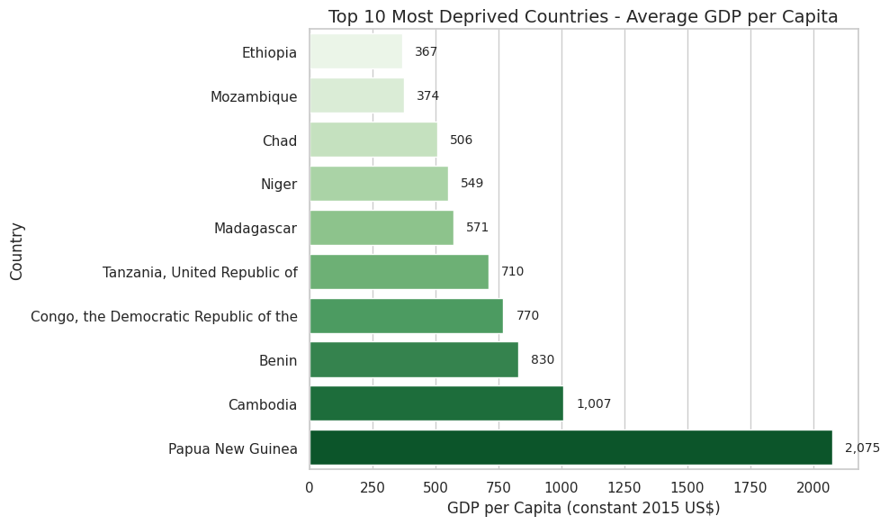

```python
import pandas as pd
import matplotlib.pyplot as plt
import seaborn as sns

top_deprived = df_deprivation.groupby("country")["obs_value"].mean().sort_values(ascending=False).head(10).index

top_gdp = merged[merged["country"].isin(top_deprived)].groupby("country")["GDP per capita (constant 2015 US$)"].mean().reset_index()

top_gdp_sorted = top_gdp.sort_values(by="GDP per capita (constant 2015 US$)")

plt.figure(figsize=(10, 6))
barplot = sns.barplot(
    data=top_gdp_sorted,
    y="country",
    x="GDP per capita (constant 2015 US$)",
    palette=sns.color_palette("Greens", len(top_gdp_sorted))
)

plt.title("Top 10 Most Deprived Countries - Average GDP per Capita", fontsize=14)
plt.xlabel("GDP per Capita (constant 2015 US$)", fontsize=12)
plt.ylabel("Country", fontsize=12)

for i, value in enumerate(top_gdp_sorted["GDP per capita (constant 2015 US$)"]):
    plt.text(value + 50, i, f"{int(value):,}", va='center', fontsize=10)

plt.tight_layout()
plt.show()
```

**This chart reveals the deep connection between economic hardship and child deprivation.**

It shows the average GDP per capita of the 10 countries where children face the highest levels of deprivation. In places like **Ethiopia** and **Mozambique**, GDP per capita is under $400 — highlighting how limited economic resources often go hand-in-hand with multidimensional poverty.

Yet even in countries with relatively higher GDPs, like **Cambodia** or **Papua New Guinea**, deprivation remains widespread. This tells us that **wealth alone isn’t enough** — it’s how that wealth is distributed and invested in children’s well-being that makes the real difference.

Ultimately, this chart is a reminder: **behind every number is a child in need of opportunity and support.**

## **Comparative analysis of child deprivation by the gender**

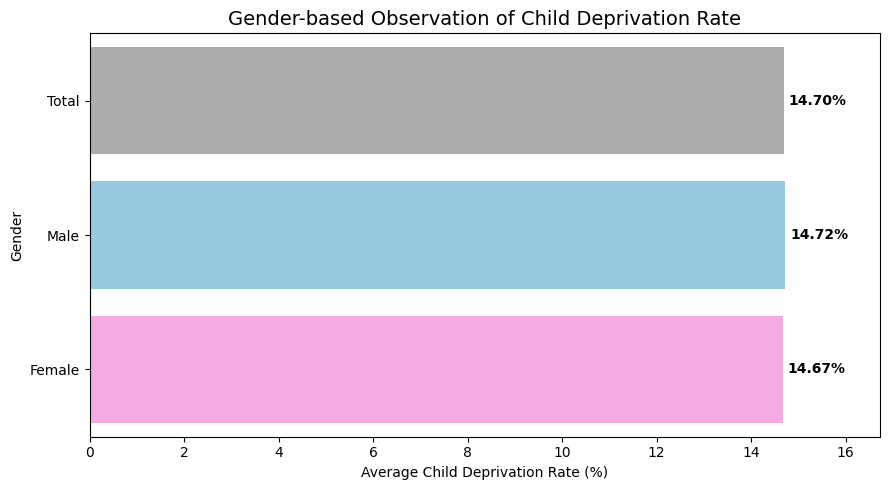

```python
import seaborn as sns
import matplotlib.pyplot as plt

# Définir les couleurs personnalisées
gender_colors = {
    "Female": "#FF9FE7",
    "Male": "skyblue",
    "Total": "#AEAAAD"
}

# Trier les genres dans l'ordre souhaité (facultatif)
df_gender["Gender"] = pd.Categorical(df_gender["Gender"], ["Total", "Male", "Female"])
df_gender = df_gender.sort_values("Gender")

# Créer le graphique
plt.figure(figsize=(9, 5))
bars = sns.barplot(
    data=df_gender,
    x="Average Deprivation Rate",
    y="Gender",
    palette=[gender_colors[gender] for gender in df_gender["Gender"]]
)

# Ajouter les annotations (valeurs à droite des barres)
for i, value in enumerate(df_gender["Average Deprivation Rate"]):
    plt.text(value + 0.1, i, f"{value:.2f}%", va="center", fontweight="bold")

# Titres et style
plt.title("Gender-based Observation of Child Deprivation Rate", fontsize=14)
plt.xlabel("Average Child Deprivation Rate (%)")
plt.ylabel("Gender")
plt.xlim(0, df_gender["Average Deprivation Rate"].max() + 2)
plt.tight_layout()
plt.show()
```

**This chart offers a gendered lens on child deprivation.**

While the overall rate hovers around **14.7%**, boys face slightly higher deprivation than girls — **14.72%** vs. **14.67%**. The difference may be small, but it invites deeper reflection: **are gendered needs equally addressed?**

Even minimal gaps can hide complex realities shaped by cultural norms and systemic biases. This reminds us that true equity means looking beyond averages to ensure **every child, regardless of gender, can thrive.**

## **Temporal Trend: Children welfare and economic growth over time**

**The story unfolds in two timelines, each telling its own side of the global development narrative.**

In the first visual, we follow the steady climb—or in some cases, the stagnation—of **GDP per capita**, a classic indicator of economic health. It traces the path of national prosperity over time, reflecting how countries have grown—or struggled—through the decades.

But numbers alone don’t tell the full story. **The second graph shifts our focus to a more human-centered lens: the evolution of child deprivation rates**. Here, we observe not just progress or decline, but the f**luctuations in child well-being**, revealing the vulnerabilities that persist even as economies evolve.

Together, these two trajectories offer a powerful contrast: while some nations may experience economic gains, **the benefits don’t always reach the most vulnerable** — especially children. These visual timelines invite us to ask: what kind of growth are we pursuing, and for whom?

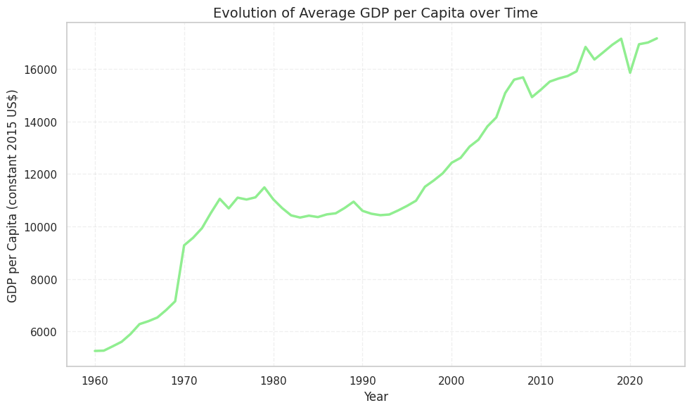

```python
import matplotlib.pyplot as plt

gdp_column = "GDP per capita (constant 2015 US$)"

df_gdp = metadata[["year", gdp_column]].dropna()

avg_gdp = df_gdp.groupby("year")[gdp_column].mean().reset_index()

plt.figure(figsize=(10, 6))
plt.plot(avg_gdp["year"], avg_gdp[gdp_column], color="lightgreen", linewidth=2.5)
plt.title("Evolution of Average GDP per Capita over Time", fontsize=14)
plt.xlabel("Year")
plt.ylabel("GDP per Capita (constant 2015 US$)")
plt.grid(True, linestyle="--", alpha=0.3)
plt.tight_layout()
plt.show()
```

The line chart illustrates a **steady and long-term increase** in average GDP per capita from 1960 to 2022, reflecting **global economic growth**. Notably, the sharp rise around the early 2000s signals a period of accelerated development, likely driven by globalization, technological progress, and expanded international trade.

Despite some fluctuations—such as the economic slowdowns around the early 1980s and during the 2008 global financial crisis—the overall trend is positive. This sustained growth suggests improvements in national incomes and economic productivity across countries, setting **a favorable context for addressing broader social challenges like poverty and child deprivation**.

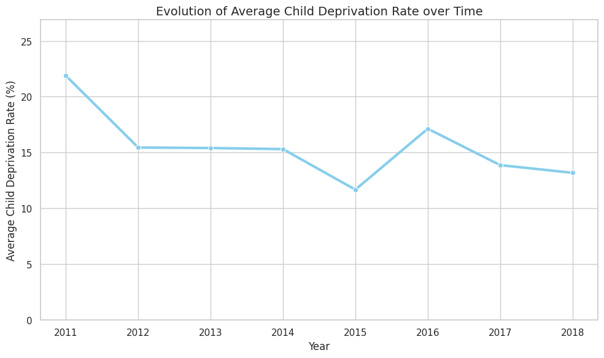

```python
import pandas as pd
import seaborn as sns
import matplotlib.pyplot as plt

df_deprivation = df[df["indicator"].str.contains("three deprivation", case=False, na=False)]

mean_by_year = df_deprivation.groupby("time_period")["obs_value"].mean().reset_index()

plt.figure(figsize=(10, 6))
sns.lineplot(
    data=mean_by_year,
    x="time_period",
    y="obs_value",
    marker="o",
    linewidth=3,
    color="skyblue"
)

plt.title("Evolution of Average Child Deprivation Rate over Time", fontsize=14)
plt.xlabel("Year")
plt.ylabel("Average Child Deprivation Rate (%)")
plt.grid(True)
plt.ylim(0, mean_by_year["obs_value"].max() + 5)
plt.tight_layout()
plt.show()
```

The line chart illustrates the progression of the average child deprivation rate between 2011 and 2018. Overall, the data reveals a **moderate downward trend**, with the rate decreasing from approximately **22% in 2011 to 13.5% in 2018**, indicating gradual improvements in child well-being over the observed period.

However, the trajectory is not entirely consistent. **A notable increase in 2016** interrupts the otherwise declining pattern, suggesting that external shocks or temporary setbacks may have influenced child deprivation during that year. Despite this anomaly, the post-2016 data resumes a declining trend, reflecting a return to positive developments.

This pattern highlights the importance of **sustained policy efforts and resilience planning**, as even short-term disruptions can significantly affect the most vulnerable populations.

This comparison suggests that although increased GDP per capita may create the potential for better living conditions, targeted social policies and equitable resource distribution are essential to ensure that children benefit from economic gains. Economic growth is a necessary foundation—but not a sufficient condition—for reducing multidimensional deprivation among children.

## **Correlation between GDP and Child Deprivation**

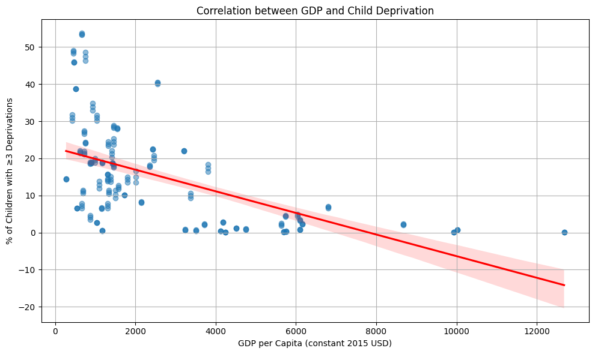

```python
plt.figure(figsize=(10, 6))
sns.regplot(
    data=merged,
    x="GDP per capita (constant 2015 US$)",
    y="obs_value",
    scatter_kws={"alpha":0.5},
    line_kws={"color":"red"}
)
plt.xlabel("GDP per Capita (constant 2015 USD)")
plt.ylabel("% of Children with ≥3 Deprivations")
plt.title("Correlation between GDP and Child Deprivation")
plt.grid(True)
plt.tight_layout()
plt.show()
```

🔍 *What stands out*: Countries with low GDPs display **wide variation** in deprivation—some do better than others, proving that **policy matters.** Above $10,000 GDP, deprivation levels are almost universally low.

This chart highlights how **economic growth helps**, but also that **smart social policies** can protect children—even in poorer nations.

## Conclusion

To conclude, the road to improving the **lives of children** in the most **deprived countries** is long, but it is not impossible. By addressing the **root causes** of deprivation—such as income **inequality**, **access to education**, and **healthcare** — and focusing on **economic development**, we can begin to **change the future** for millions of children. But we must act now.

**The data is clear: the longer we wait, the harder it will be to break the cycle of poverty and deprivation that holds these children back.**